# DV Final Exam

December 1, 2017

### Instructions

#### Part 1: Visual Choices

The following three questions contain R plots that do not align with the principles of Data Visualization, as discussed in our class and in the reading Data Points. Correct the plots using your knowledge of ggplot2.

**EXAMPLE**  
*Question*  
The following is an example of an initial graph. There are three primary lines that need change in order to improve.

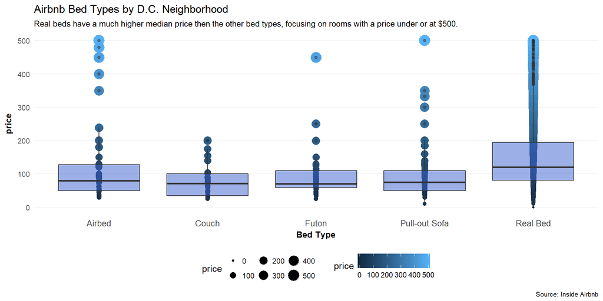

*Answer*  
The following is an example of a corrected answer. There are three lines were changed to improve the readability of the graph, and each one has a comment explaining the rationale behind the change.

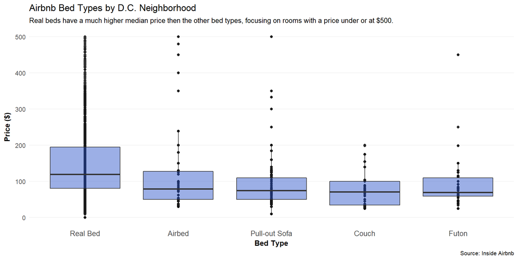

```r
q0 <- listingsAll %>%
  filter(!is.na(bed_type)) %>%
  filter(price <= 500)

# The boxplots need to be sorted in a meaningful way in order to
# draw attention to the important insight: The bed type with the
# highest median price is "real beds."
ggplot(data=q0, aes(x=reorder(bed_type, -price, FUN=median), y=price)) +
  # It was redunant to use size or color as a visual cue for price when price is already
  # on the y-axis so I eliminated them.
  geom_point(fill="grey50")+
  geom_boxplot(fill="royalblue3", alpha=0.5)+
  theme_minimal() +
    theme( axis.title.x = element_text(size=10, face="bold"),
        axis.title.y = element_text(size=10, face="bold"),
        axis.text.x = element_text(size=10),
        legend.position="bottom",
        panel.grid.major.x = element_blank(),
        panel.grid.major.y = element_line(color="grey95"),
        panel.grid.minor = element_blank(),
        plot.caption = element_text(size=8)) +
  # The y-axis should have labels to make it easier to read.
  labs(x = "Bed Type", y="Price ($)",
       title="Airbnb Bed Types by D.C. Neighborhood",
       subtitle="Real beds have a much higher median price then the other bed types, focusing on rooms with a price under or at $500.",
       caption="Source: Inside Airbnb")
```

**1. Listings per neighborhood**

This plot is supposed to show the number of listings for each neighborhood. The goal of the graphic is to provide a heatmap of the number of listings for each type, potentially seeing the distribution of room types per neighborhood, as discussed in the plot subtitle.

*(6 pts)*

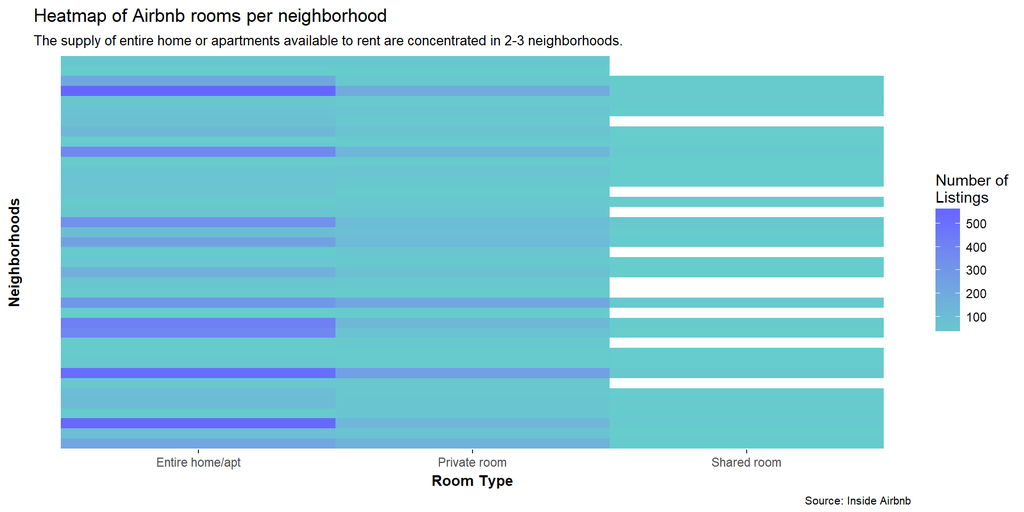

In this plot, I changed three things: * I changed the scale of color because original color is hard to read and made me feel dizzy. * I add a x-axis title because it is important for readers to know what are on axises. * I removed numbers in the original plot. Since this plot is a heatmap and we want to see the distribution potentially, actual numbers are not necessary.

**2. Neighborhoods and price**

This plot is supposed to show that the most popular neighborhoods, as measured by the number of listsings, do not necessarily have the highest prices for available rooms. The goal is to combine information about the most popular neighbors with information about the price and the number of available listings.

*(6 pts)*

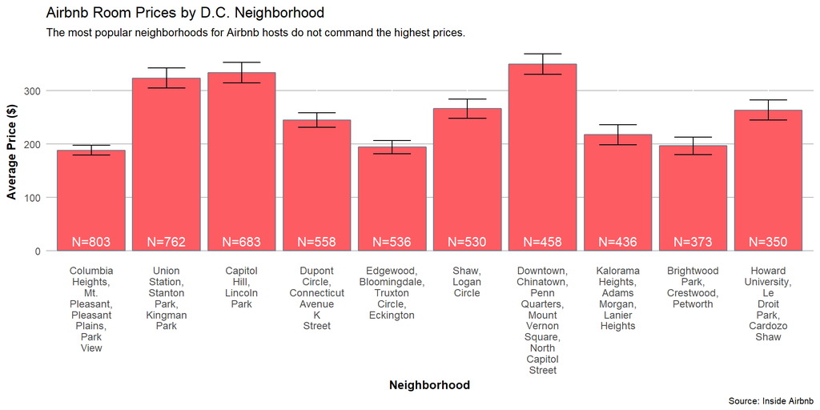

I changed five things in this plot: * Since we want to show the most popular neighborhoods do not necessarily have the highest prices for available rooms, I reordered bars to let readers see the most neighborhood first. * I changed the color to fill bars. Different colors mean nothing in this case, so I changed it to the color of Airbnb logo. * I removed the vertical background grid lines because it’s a little distracting. But I kept horizontal grid lines and changed its color to grey because it can help us estimate average prices. * As always, I add a x-axis title. * I changed the font size of x-axis text and text at the bottom of bars so it’s easier to read.

**3. Room types and price**

This graph is supposed to show the average price among the property types. For this graph in particular, consider the type of data that you want to plot, and you may want to refer to Chapter 4 of Data Points as to what types of plots are appropriate.

*(6 pts)*

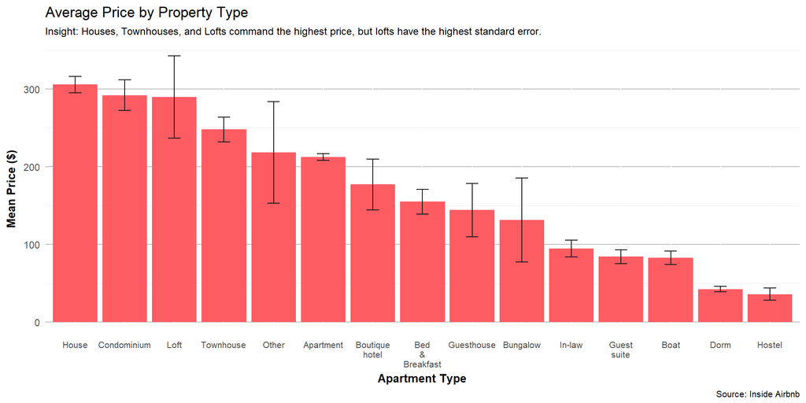

I changed three things in this plot: * Since we want to compare the average price and standard error across apartment type, I decided to use barchart. And I reordered bars by average price. * I removed vertical grid lines because they will overlap with errorbars. And I changed the color of horizontal grid lines to grey. * I changed font sizes of subtitle, x-axis text and caption to make them easier to read.

### Part 2: Errors

The following two questions contain errors that prevent the script from executing. Correct the errors in order to have a functional script that creates that described graph.

**4. Room types with ggvis**

This graph is supposed to be a tool to help explore the relationship between num_listings, room_type, property type, and neighborhood that were discussed in the first three graphs.

*(6 pts)*

**5. Host network** The following script plots the co-stay network of hosts. Each node is a host, and the host ties represent hosts with common reviewers. Put differently, some reviewers stay with different hosts, and those hosts may have common attributes (i.e., apartments, similar neighborhoods, etc.). To understand the relationships among hosts, you should plot the network of hosts.

The host network has been restricted to 2013 visits. The nodes are colored by their degree (or the number of hosts that they are connected to by reviewers). The edges are colored by the number of reviewers that the connected hosts have in common.

*(6 pts)*

### Part 3. Insights

Given what you learned in the five preceding exervises, tell me something interesting about this data related to either the price, review scores, the most desirable neighborhood (as a host) and/or the network of hosts. You are welcome to use any package, including Shiny. If you choose to create a Shiny app, please write that below and submit that R script separately.